# **Panorama da inflação**

# IPCA

O Indíce de Preços ao Consumidor Amplo (IPCA) variou 0.25% em janeiro, valor superior ao mesmo período do ano anterior quando apresentou uma taxa de 0.21%. Com esse resultado o indíce acumula no ano uma variação positiva de 0.25%, e em 12 meses uma variação positiva de 4.56%.

|  | 01/2020 | 12/2020 | 01/2021 |
| --- | --- | --- | --- |
| Variação mensal | 0.21% | 1.35% | 0.25% |
| Variação acumulada no ano | 0.21% | 4.52% | 0.25% |
| Variação acumulada em 12 meses | 4.19% | 4.52% | 4.56% |

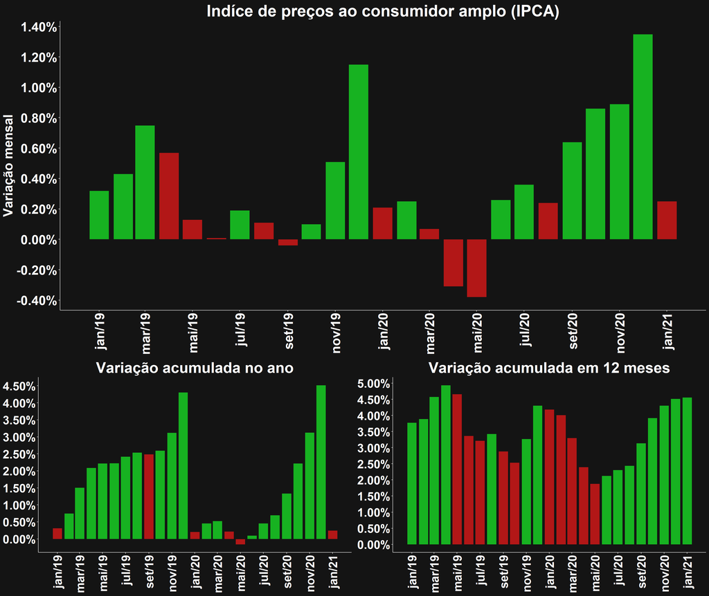

Os grupos que tiveram maior resultado positivo foram Alimentação e bebidas (1.02%) e Artigos de residência (0.86%), e negativo Habitação (-1.07%) e Vestuário (-0.07%).

|  | Variação mensal | Variação acumulada no ano | Peso mensal |
| --- | --- | --- | --- |
| Alimentação e bebidas | 1.02% | 1.02% | 21.12% |
| Habitação | -1.07% | -1.07% | 15.71% |
| Artigos de residência | 0.86% | 0.86% | 3.81% |
| Vestuário | -0.07% | -0.07% | 4.33% |
| Transportes | 0.41% | 0.41% | 19.92% |
| Saúde e cuidados pessoais | 0.32% | 0.32% | 13.14% |
| Despesas pessoais | 0.39% | 0.39% | 10.38% |
| Educação | 0.13% | 0.13% | 5.95% |
| Comunicação | 0.02% | 0.02% | 5.66% |

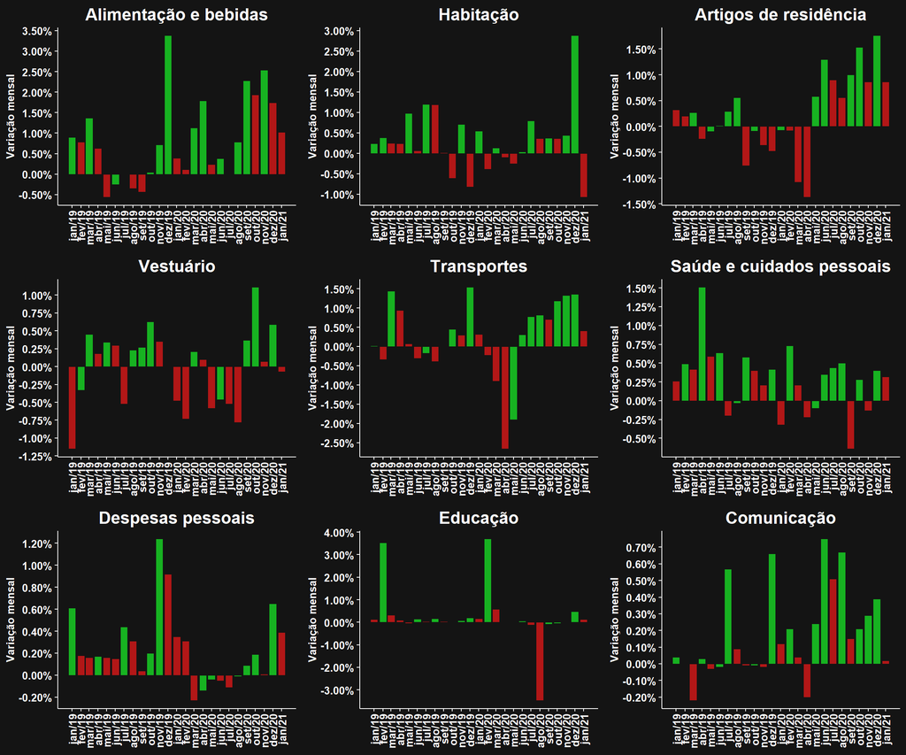

A nível de sub-itens os que mais influenciaram positivamente no resultado em relação ao seu peso foram Gasolina (2.17%%) e Automóvel novo (1.31%%), e negativamente Energia elétrica residencial (-5.6%%) e Passagem aérea (-19.93%%).

|  | Variação mensal | Variação acumulada no ano | Peso mensal |
| --- | --- | --- | --- |
| Gás de botijão | 3.19% | 3.19% | 1.11% |
| Gasolina | 2.17% | 2.17% | 4.92% |
| Lanche | 1.83% | 1.83% | 1.71% |
| Automóvel novo | 1.31% | 1.31% | 2.95% |

|  | Variação mensal | Variação acumulada no ano | Peso mensal |
| --- | --- | --- | --- |
| Leite longa vida | -1.35% | -1.35% | 0.75% |
| Transporte por aplicativo | -12.08% | -12.08% | 0.2% |
| Passagem aérea | -19.93% | -19.93% | 0.55% |
| Energia elétrica residencial | -5.6% | -5.6% | 4.6% |

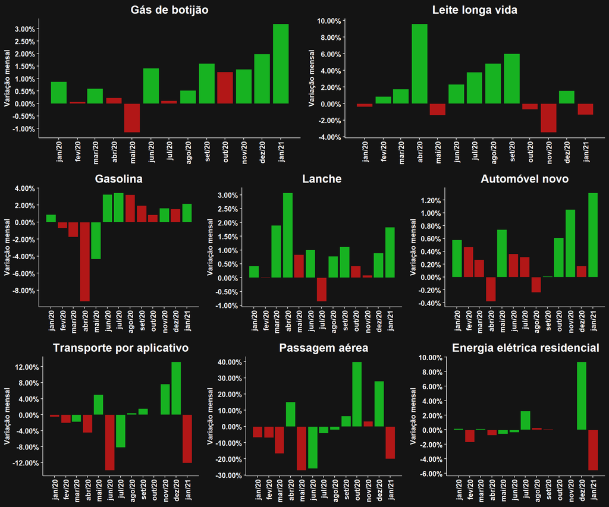